Regresión Lineal Simple - Semana 01

Freddy Hernández

fhernanb@unal.edu.co

Profesor Asociado - Departamento de Estadística

Universidad Nacional de Colombia, Sede Medellín

Introducción

En muchas ocasiones es posible diseñar experimentos estadísticos controlados, en los

cuáles es factible el estudio simultáneo de varios factores, aplicando procedimientos de

aleatorización apropiados, en lo que se conoce como diseño y análisis de experimentos.

Sin embargo, en muchas ocasiones sólo se cuenta con un conjunto de datos sobre los

cuáles es difícil esperar que hayan sido observados en condiciones estrictamente

controladas, y de los cuáles también en pocas ocasiones se tienen réplicas para calcular

el error experimental.

Cuando se enfrenta la situación anterior lo más apropiado es aplicar los métodos de

regresión, que permiten establecer asociaciones entre variables de interés, donde la

relación usual no es necesariamente de causa - efecto. En principio, consideramos una

asociación lineal entre una variable respuesta Yy una variable predictora X.

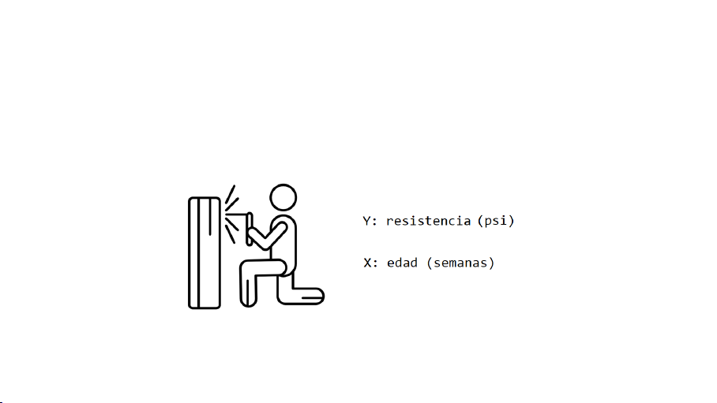

Ejemplo

Como ilustración vamos a usar los datos del ejemplo 2.1 del libro E. &. V. Montgomery

D. & Peck (2006). En el ejemplo 2.1 los autores desean crear un modelo de regresión

lineal simple para explicar la Resistencia de una soldadura en función de la Edad de la

soldadura.

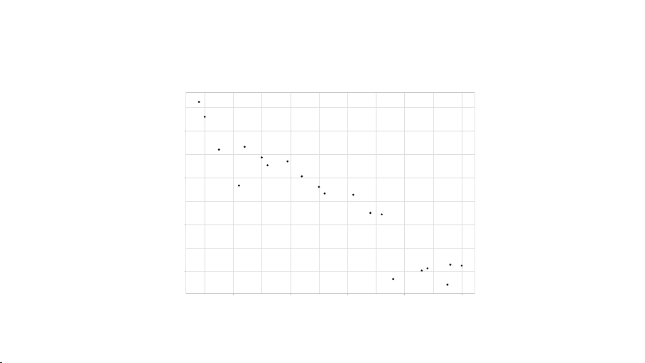

Ejemplo

Veamos una gráﬁca de dispersión de los datos:

Edad

Resistencia

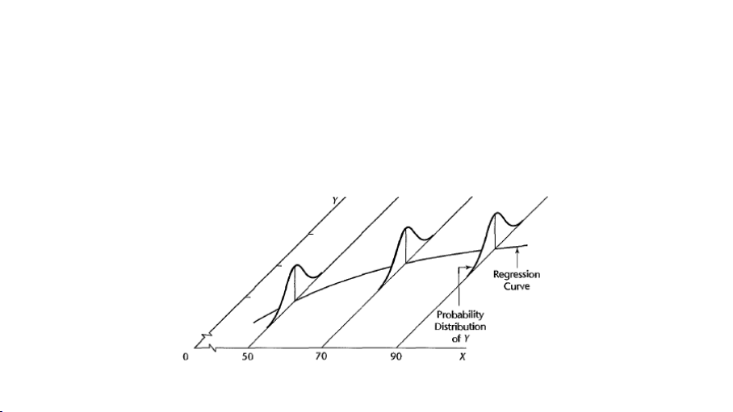

Signiﬁcados de la regresión

La regresión tiene dos signiﬁcados:

1.

(Enfoque probabilístico - Método de máxima verosimilitud ). Podemos verla a

partir de la distribución conjunta de las variables XeY, en la cual podemos deﬁnir

la distribución condicional de

Y|X

, esto es

f(Y|X)

, y determinar

E(Y|X)

. En este

caso la regresión pretende ajustar la curva correspondiente a E(Y|X).

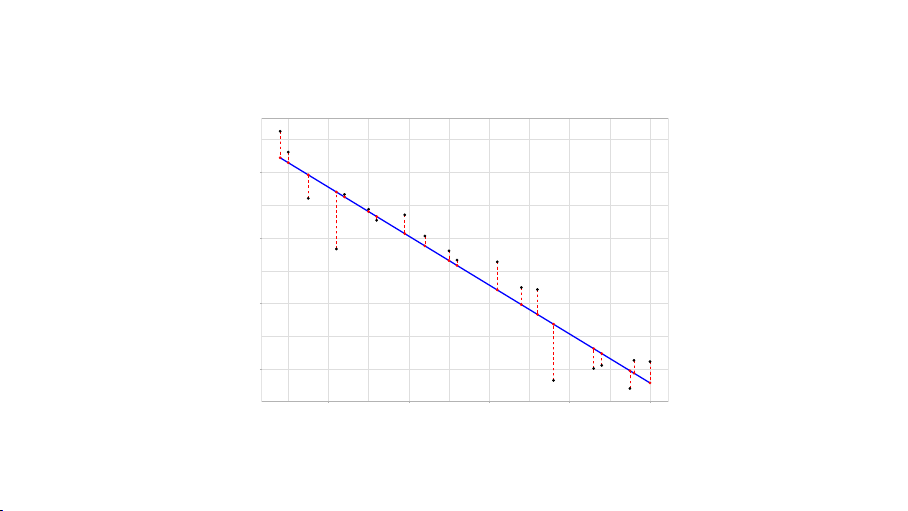

2. (Enfoque no probabilístico - Método de mínimos cuadrados). Dado un

conjunto de pares de datos (X,Y), puede asumirse una forma funcional para la

curva de regresión y tratar de ajustarla a los datos minimizando el error de ajuste.

Edad

Resistencia

El segundo caso es el que más se da en la práctica.

Supuestos bajo un enfoque probabilístico

▶

La variable respuesta Yes una variable aleatoria cuyos valores se observan mediante

la selección de los valores de la variable predictora Xen un intervalo de interés.

▶

Por lo anterior, la variable predictora Xno es considerada como variable aletatoria,

sino como un conjunto de valores ﬁjos que representan los puntos de observación,

que se seleccionan con anticipación y se miden sin error.

Sin embargo, si esto último no se cumple, el método de estimación de mínimos

cuadrados ordinarios para los parámetros del modelo de regresión puede seguir

siendo válidos si los errores en los valores de la variable predictora son pequeños en

comparación con los errores aleatorios del modelo εi.

7 / 63

▶

Los datos observados

(xi,yi),i=1,...,n

, constituyen una muestra representativa

de un medio acerca del cual se desea generalizar. Si no es así, no es apropiado

realizar inferencias en un rango de los datos por fuera del considerado.

▶

El modelo de regresión es lineal en los parámetros. Es decir, ningún parámetro de la

regresión aparece como el exponente o es dividido o multiplicado por otro

parámetro, o cualquier otra función.

Sin embargo, la línea de ajuste puede tener una curvatura (no ser lineal en Xy/o

en Y), caso en el cual mediante una transformación conveniente de las variables (X

y/o Y), es posible aplicar las técnicas de regresión lineal sobre estas nuevas

variables.

8 / 63

▶Si la ecuación de regresión seleccionada es correcta, cualquier variabilidad en la

variable respuesta que no puede ser explicada exactamente por dicha ecuación, es

debida a un error aleatorio.

▶Los valores observados de la variable respuesta no se encuentran estadísticamente

correlacionados. Se supone que cada valor observado de Yestá constituído por un

valor real y una componente aleatoria.

▶El modelo de regresión con una muestra de npares de datos (Xi,Yi)es:

Yi=Y|Xi=E[Y|Xi] + εi,i=1,2,...,n(2.1)

con

E[Y|Xi] = β0+β1Xi

9 / 63

▶Los errores aleatorios εi∼N(0, σ2),i=1,2,...,n.

▶Los errores aleatorios εison estadísticamente independientes.

Por tanto:

COV (εi, εj) = 0,∀i=j,COV (Yi,Yj) = 0,∀i=j.

▶La varianza de los errores aleatorios es σ2,∀i=1,2,...,n(supuesto de varianza

constante pero desconocida).

Dado que los valores Xide la variable predictora no son considerados aleatorios y

que los errores son independientes, la varianza de los Yitambién es σ2,∀iy por

tanto este parámetro es independiente del punto de observación (es decir, del valor

de X).

Pero en el caso que este último supuesto no pueda aplicarse, entonces el método de

regresión empleado será el de mínimos cuadrados ponderados.

10 / 63

En resumen, los supuestos del modelo de regresión lineal simple se pueden expresar

como:

εi

iid.

∼N(0, σ2),i=1,2,...,n

donde, iid. es la abreviación de independiente e idénticamente distribuido.

Estos supuestos tienen como consecuencia directa en la respuesta que:

Y|Xi

ind.

∼Nβ0+β1Xi, σ2

donde, ind. es la abreviación de independiente distribuido.

11 / 63

Nomenclatura

▶Y: Variable respuesta o dependiente.

▶X: Variable predictora, independiente o regresora.

▶ε: Error aleatorio

▶β0,β1: Parámetros de la regresión. β0es el intercepto y β1es la pendiente de la

línea recta.

▶b

β0: Estimador del parámetro β0.

▶b

β1: Estimador del parámetro β1.

▶e: Residual, es una estimación del error aleatorio.

▶b

Y: Es la estimación de E(Y|X)óµY|X.

12 / 63

Estimación por mínimos cuadrados ordinarios (MCO)

Para una selección preliminar de la variable predictora en un modelo de regresión simple

(o sea que considera una sola variable predictora) es conveniente realizar el diagrama de

dispersión Yvs. Xy mirar si existe una tendencia lineal en la nube de puntos.

Si la nube de puntos parece mejor ajustada por una curva hay que buscar una

transformación apropiada en Xy/o Yque lleve a un modelo lineal; en este caso el

modelo de regresión lineal a ajustar será: Y∗|X∗

i=β0+β1X∗

i+εi,i=1,2,...,n,

donde Y∗yX∗son las variables YyXtransformadas. Más adelante se ampliará el

tema de transformaciones que llevan a un modelo lineal.

Debe tenerse claro que el método de mínimos cuadrados es un método numérico, no

estadístico. La estadística opera a partir de los supuestos distribucionales asignados en el

modelo de regresión.

13 / 63

Objetivo del método MCO

Obtener estimaciones de los parámetros de regresión, es decir hallar valores de β0yβ1

que minimicen la suma de los cuadrados de los errores S(β0, β1)deﬁnida a partir de

(2.1) como:

S(β0, β1) =

n

X

i=1

ε2

i=

n

X

i=1Yi−(β0+β1Xi)2

A los valores que minimizan esta expresión se les conoce como estimadores de mínimos

cuadrados y se les denota b

β0yb

β1.

14 / 63

Valor de los estimadores MCO

Dados los pares de observaciones (x1,y1),...,(xn,yn), hallar β0yβ1que minimicen a

S(β0, β1)implica resolver el siguiente sistema de ecuaciones:

∂S(β0, β1)

∂β0b

β0,b

β1

=0

∂S(β0, β1)

∂β1b

β0,b

β1

=0

15 / 63

De lo cual surgen las denominadas ecuaciones normales:

n

X

i=1

yi=nb

β0+b

β1

n

X

i=1

xi

n

X

i=1

xiyi=b

β0

n

X

i=1

xi+b

β1

n

X

i=1

x2

i

16 / 63

[figure not shown]

Y de éstas se obtiene que las estimaciones por mínimos cuadrados de los parámetros son:

b

β0= ¯y−b

β1¯x

b

β1=Sxy

Sxx

Las cantidades Sxx ySxy se muestran a continuación.

17 / 63

Sumas de cuadrados y de productos cruzados

▶Suma de cuadrados corregidos en x:

Sxx =

n

X

i=1

(xi−¯x)2=

n

X

i=1

x2

i−n¯x2

▶Suma de cuadrados corregidos en y:

Syy =

n

X

i=1

(yi−¯y)2=

n

X

i=1

y2

i−n¯y2

▶Suma de productos cruzados corregidos:

Sxy =

n

X

i=1

(xi−¯x)(yi−¯y) =

n

X

i=1

(xi−¯x)yi

18 / 63

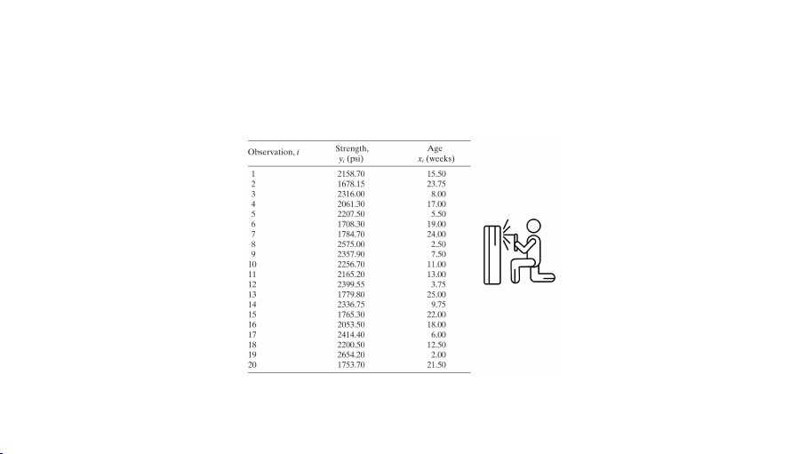

Ejemplo

Estimar los parámetros del modelo de regresión lineal simple para explicar la resistencia

en función de la edad de la soldadura.

19 / 63

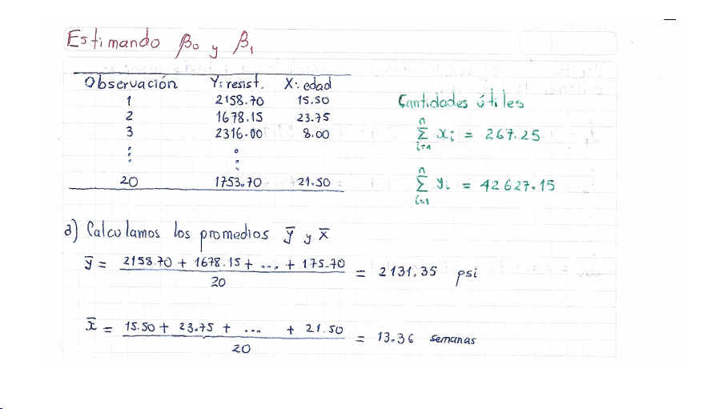

20 / 63

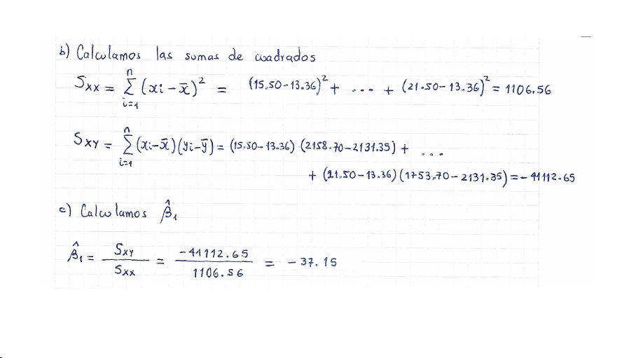

21 / 63

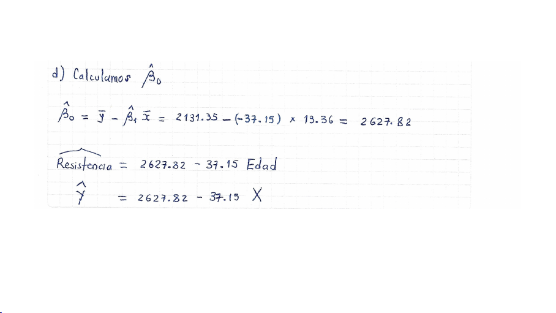

22 / 63

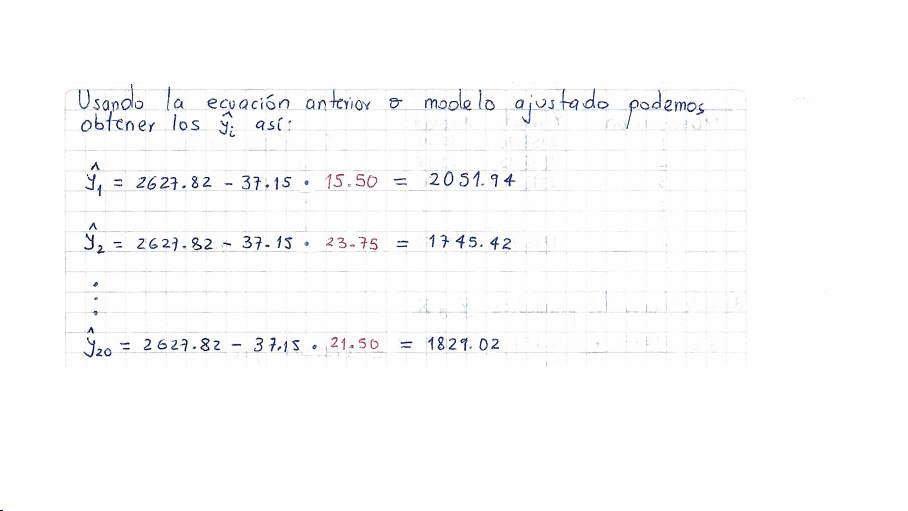

23 / 63

Estimación por máxima verosimilitud (ML)

El método de mínimos cuadrados produce los mejores estimadores lineales insesgados

para los parámetros de la recta y puede ser usado para la estimación de parámetros de

un modelo de regresión lineal sin consideraciones distribucionales sobre los errores.

Sin embargo, para poder aplicar pruebas de hipótesis y construir intervalos de conﬁanza,

es necesario realizar y validar tales supuestos. Considerando para el modelo de regresión

lineal simple los supuestos de normalidad, independencia y varianza constante para los

errores, podemos usar el método de estimación de máxima verosimilitud (MLE).

Sean (x1,y1),...,(xn,yn)los npares de datos observados, entonces el modelo de

regresión lineal simple es:

Yi=Y|Xi=β0+β1Xi+εi,i=1,2,...,n.

24 / 63

A la variable aleatoria εi, se le asignan los siguientes supuestos distribucionales:

εi

iid.

∼N0, σ2,i=1,2,...,n,

Con base en lo anterior y asumiendo que los niveles o valores en que Xes observada son

ﬁjos, se obtiene que

Yi=Y|Xi

ind.

∼NE[Y|Xi], σ2

con

E[Y|Xi] = β0+β1Xi

25 / 63

Sean x= (x1,x2,...,xn)yy= (y1,y2,...,yn), entonces la función de verosimilitud

L(β0, β1, σ2x,y)es hallada a partir de la densidad conjunta de las observaciones,

f(y1,...,yn|β0, β1, σ2)

, que por la condición de independencia es igual al producto de

las densidades de probabilidad marginales, por tanto, podemos escribir,

Lβ0, β1, σ2x,y=fy1,...,ynβ0, β1, σ2

=

n

Y

i=1

1

√2πσ2exp −1

2σ2(yi−β0−β1xi)2

= (2πσ2)−n/2exp "−1

2σ2

n

X

i=1

(yi−β0−β1xi)2#

26 / 63

El objetivo es hallar los parámetros desconocidos β0, β1, σ2, que maximicen L, o

equivalentemente, que maximicen ℓ= ln L(el logaritmo natural de L).

ℓ= ln L=−n

2ln(2π)−n

2ln(σ2)−1

2σ2

n

X

i=1

(yi−β0−β1xi)2

Observe que para cualquier valor de

σ2

ﬁjo,

ℓ

es maximizada como una función de

β0

y

β1por aquellos valores e

β0ye

β1que minimizan S(β0, β1) = n

P

i=1

(yi−β0−β1xi)2y así,

los estimadores MLE e

β0ye

β1son iguales a los respectivos estimadores de mínimos

cuadrados, b

β0yb

β1.

27 / 63

Para hallar el estimador MLE para σ2substituimos b

β0yb

β1en ln L, y hallamos σ2que

maximiza

−n

2ln(2π)−n

2ln(σ2)−1

2σ2

n

X

i=1

(yi−b

β0−b

β1xi)2

de donde obtenemos como estimador MLE de σ2a

e

σ2=1

n

n

X

i=1

(yi−b

β0−b

β1xi)2=1

n

n

X

i=1

(yi−b

yi)2

28 / 63

Resumiendo, bajo el modelo de regresión lineal normal, es decir, con errores

independientes e idénticamente distribuidos N0, σ2, los estimadores de mínimos

cuadrados para

β0

y

β1

son también estimadores de máxima verosimilitud y en tal caso,

podemos construir intervalos de conﬁanza y realizar pruebas de hipótesis basadas en las

estimaciones obtenidas.

También puede demostrarse que los estimadores MLE son de mínima varianza cuando

son comparados con todos los posibles estimadores insesgados y son consistentes, es

decir, a medida que aumenta el tamaño de muestra, la diferencia entre éstos y los

respectivos parámetros se aproxima a cero.

29 / 63

Ecuación de regresión ajustada

Al tener estimados los parámetros del modelo de regresión lineal simple (por mínimos

cuadrados o máxima verosimilitud), entonces se puede realizar una estimación de la

respuesta media E[Y|X] = µY|X, a través del modelo ajustado, así:

b

µY|xi=b

yi=b

β0+b

β1xi= ¯y+ (xi−¯x)b

β1.

A esta ecuación se le conoce como la ecuación de regresión ajustada, que en este caso

corresponde a una recta ajustada.

30 / 63

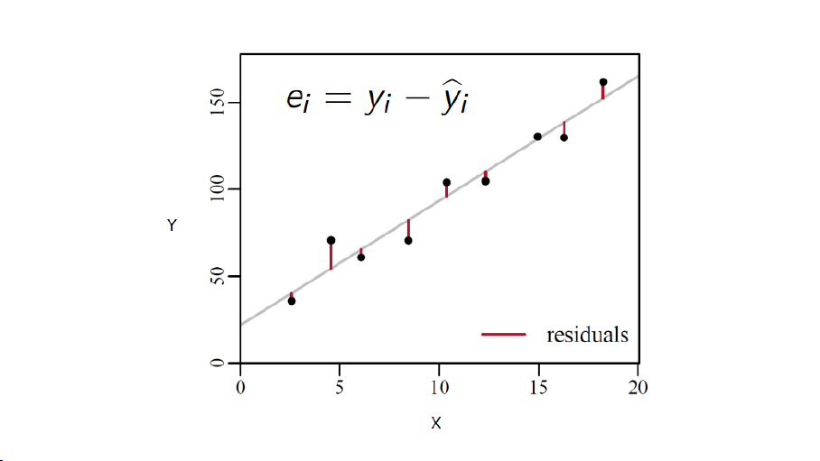

Residuales del modelo

31 / 63

A las diferencias entre los valores observados de la respuesta yiy los valores ajustados

por el modelo de regresión b

yi(obtenidos de la ecuación de regresión ajustada) se les

conoce como los residuales del modelo. Esto es, ei=yi−b

yies el i-ésimo residual del

modelo, que es una estimación del i-ésimo error aleatorio, εi.

Los residuales del modelo tienen gran importancia ya que ellos determinan que tan

bueno fue el ajuste del modelo y permitirán más adelante realizar las validaciones de los

supuestos realizados sobre los errores aleatorios.

32 / 63

Estimación de la varianza σ2

Puede demostrarse que bajo los supuestos del modelo en relación a los errores, la

esperanza del estimador de máxima verosimilitud de σ2es:

Ehe

σ2i=n−2

nσ2

por tanto e

σ2no es un estimador insesgado de σ2, aunque si es asintóticamente

insesgado, esto es, lim

n→∞ Ee

σ2=σ2. Sin embargo, a partir de e

σ2se puede obtener un

estimador insesgado de la varianza, así:

b

σ2=n

n−2e

σ2=

n

P

i=1

(yi−b

yi)2

n−2

que cumple Eb

σ2=σ2.

33 / 63

[figure not shown]

Como yi−ˆyi=ei, la fórmula para estimar σ2se puede escribir así:

b

σ2=

n

P

i=1

e2

i

n−2=SSRes

n−2≡MSRes .

▶SSRes es la suma de los cuadrados de los residuales (sum of squared residuals).

▶MSRes es la media de los cuadrados de los residuales (mean of squared residuals).

Nota: la cantidad ˆσrecibe el nombre “Residual standard error”.

34 / 63

[figure not shown]

Calcular SSRes =n

P

i=1

e2

ipuede ser muy demorado. Existe una relación con dos

ecuaciones que nos permite obtener SSRes un poco más facil.

Los pasos para obtener SSRes son:

▶Calcular la suma de cuadrados totales SST=n

P

i=1

y2

i−n¯y2.

▶Luego reemplazar SSTen la ecuación SSRes =SST−ˆ

β1Sxy .

▶Listo, ya tenemos SSRes .

35 / 63

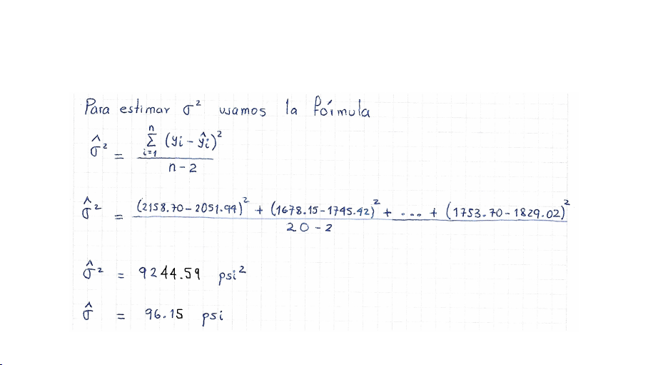

Ejemplo

Estimar el parámetro

σ2

del modelo de regresión lineal simple para explicar la resistencia

en función de la edad de la soldadura.

36 / 63

Propiedades de los estimadores de mínimos cuadrados

Bajo los supuestos considerados respecto a los errores tenemos que:

1. b

β0

y

b

β1

son combinaciones lineales de las variables aleatorias

Y1,...,Yn

, pues estos

pueden escribirse como:

b

β0=

n

X

i=1

miYi

b

β1=

n

X

i=1

ciYi

37 / 63

donde:

mi=1

n−¯x ci

ci=xi−¯x

Sxx

Se puede demostrar a través de cálculos directos que:

n

X

i=1

ci=0,

n

X

i=1

cixi=1,

n

X

i=1

mi=1,

n

X

i=1

mixi=0,

n

X

i=1

c2

i=1

Sxx

,

n

X

i=1

m2

i=

n

P

i=1

x2

i

nSxx

.

38 / 63

Además, como Y1,...,Ynson variables normales e incorrelacionadas, entonces b

β0yb

β1

son variables aleatorias normales.

2. El valor esperado de los estimadores, es:

Ehb

β0i=E"n

X

i=1

miYi#=

n

X

i=1

miE[Yi]

=

n

X

i=1

mi(β0+β1xi)

=β0

n

X

i=1

mi+β1

n

X

i=1

mixi=β0

Ehb

β1i=E"n

X

i=1

ciYi#=

n

X

i=1

ciE[Yi]

=

n

X

i=1

ci(β0+β1xi) = β0

n

X

i=1

ci+β1

n

X

i=1

cixi=β1

39 / 63

3. La varianza de los estimadores, es:

Vhb

β0i=V"n

X

i=1

miYi#=

n

X

i=1

m2

iV[Yi]

=

n

X

i=1

m2

iσ2

=σ2Pn

i=1x2

i

n Sxx

Vhb

β1i=V"n

X

i=1

ciYi#=

n

X

i=1

c2

iV[Yi]

=

n

X

i=1

c2

iσ2

=σ2

Sxx

40 / 63

4. La varianza de la respuesta ajustada en un valor dado X=xi, es:

Vhb

Yii=Vhb

β0+b

β1xii

=V

n

X

j=1

(mj+xicj)Yj

=

n

X

j=1

(mj+xicj)2V(Yj)

=σ2

n

X

j=11

n+ (xi−¯x)cj2

=σ2"1

n+(xi−¯x)2

Sxx #

41 / 63

5. La covarianza (cov) entre los estimadores de los parámetros es:

cov hb

β0,b

β1i=cov "n

X

i=1

miYi,

n

X

i=1

ciYi#

=

n

X

i=1

micicov [Yi,Yi] +

n

X

i=1

n

X

j=i

micjcov [Yi,Yj]

=

n

X

i=1

miciV[Yi]

=σ2

n

X

i=1

mici

cov hb

β0,b

β1i=−σ2¯x

Sxx

42 / 63

6.

La covarianza entre la variable respuesta y su correspondiente estimador en un valor

dado X=xies:

cov hYi,b

Yii=cov hYi,b

β0+b

β1xii

=cov

Yi,

n

X

j=1

(mj+xicj)Yj

= (mi+xici)cov [Yi,Yi] +

n

X

j=i

(mj+xicj)cov [Yi,Yj]

=σ2(mi+xici)

=σ2"1

n+(xi−¯x)2

Sxx #

43 / 63

7. La suma de los residuales del modelo de regresión con intercepto es siempre cero:

n

X

i=1

ei=0

8.

La suma de los valores observados

yi

es igual a la suma de los valores ajustados

b

yi

:

n

X

i=1

yi=

n

X

i=1b

yi

44 / 63

9. La línea de regresión siempre pasa a través del centroide de los datos (¯x,¯y).

10. La suma de los residuales ponderados por el correspondiente valor de la variable

predictora es cero: n

X

i=1

xiei=0

11. La suma de los residuales ponderados por el correspondiente valor ajustado es

siempre igual a cero: n

X

i=1b

yiei=0

45 / 63

[figure not shown]

Error estándar de las estimaciones

Los valores estimados

ˆ

β0

y

ˆ

β1

toman valores diferentes al cambiar la muestra con la cual

se entrena el modelo. La desviación de esos estimadores se llama error estándar y se

nota por se(). Las expresiones para obtener los errores estándar son:

se(b

β0) = sˆσ2Pn

i=1x2

i

n Sxx

se(b

β1) = sˆσ2

Sxx

46 / 63

[figure not shown]

Inferencias sobre los parámetros del modelo de regresión

47 / 63

Inferencia sobre β0

Se puede demostrar que bajo los supuestos del modelo de regresión, se cumple que

T=b

β0−β0

rbσ2Pn

i=1x2

i

nSxx

∼tn−2(2.2)

con tn−2la variable aleatoria t-Student con n−2 grados de libertad.

48 / 63

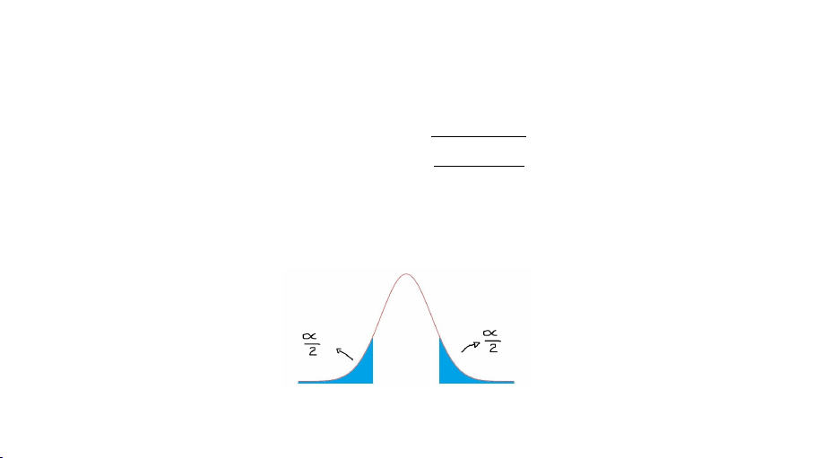

Intervalo de conﬁanza para β0

El intervalo de conﬁanza del (1−α)% para β0es:

b

β0±tα/2,n−2×sb

σ2Pn

i=1x2

i

nSxx

,

donde tα/2,n−2es el percentil (1−α/2)de la distribución t-Student con n−2 grados

de libertad.

49 / 63

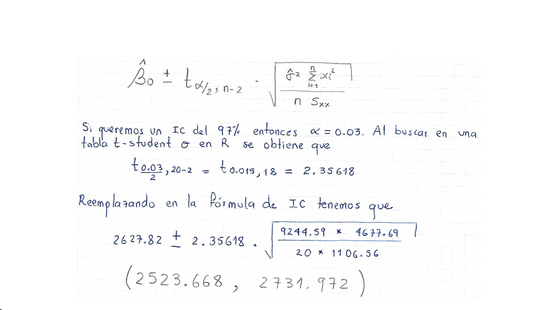

Ejemplo

Encontrar un intervalo de conﬁanza del 97 por ciento para β0.

50 / 63

Prueba de Hipótesis sobre la signiﬁcancia del intercepto

Para probar si β0es signiﬁcativamente distinto de cero:

H0:β0=0

H1:β0=0

El estadístico de prueba es la ec. (2.2) y el valor observado de éste (T0) se halla

reemplazando β0por 0. Se rechaza H0si |T0|>tα/2,n−2.

51 / 63

Inferencias sobre la pendiente β1

Se puede demostrar que bajo los supuestos del modelo de regresión, se cumple que:

T=b

β1−β1

qbσ2

Sxx

∼tn−2(2.3)

con tn−2la variable aleatoria t-Student con n−2 grados de libertad.

52 / 63

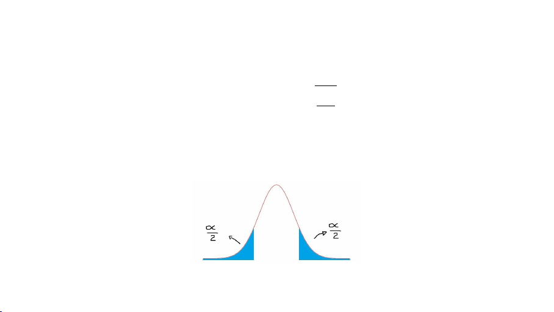

Intervalo de conﬁanza para β1

El intervalo de conﬁanza del (1−α)% para β1es:

b

β1±tα/2,n−2×sb

σ2

Sxx

,

donde tα/2,n−2es el percentil (1−α/2)de la distribución t-Student con n−2 grados

de libertad.

53 / 63

Prueba de Hipótesis sobre la signiﬁcancia de la pendiente

Para probar si β1es signiﬁcativamente distinto de cero:

H0:β1=0

H1:β1=0

El estadístico de prueba es la ec. (2.3) y el valor observado de éste (T0) se halla

reemplazando β1por 0. Se rechaza H0si |T0|>tα/2,n−2.

NOTA: Note que si la pendiente es signiﬁcativa, entonces el modelo de RLS entre la

predictora y la respuesta, también lo es.

54 / 63

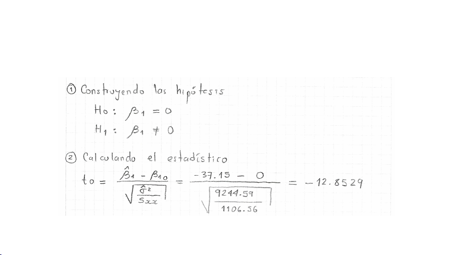

Ejemplo

¿Es la variable Edad signiﬁcativa para el modelo? ¿La variable Edad ayuda a explicar la

Resistencia? Use un nivel de signiﬁcancia del 3 por ciento.

55 / 63

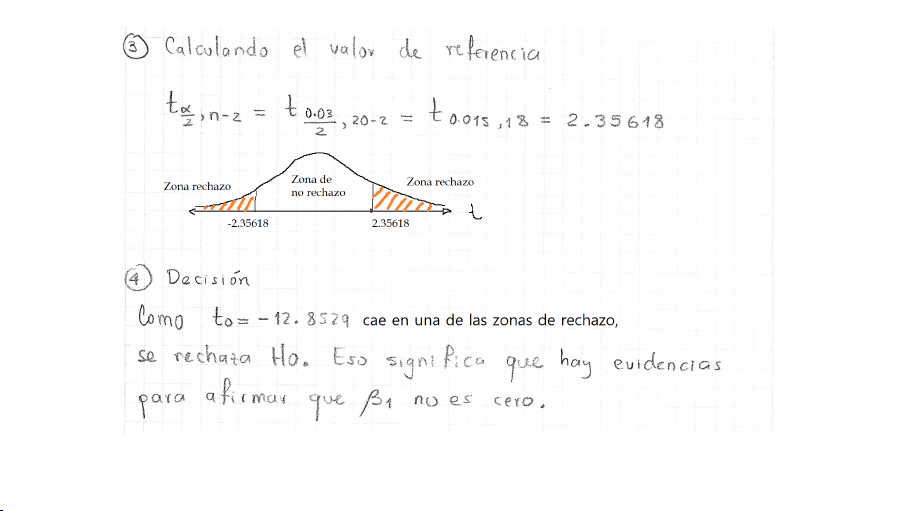

56 / 63

[figure not shown]

Pruebas de hipótesis generales sobre β0yβ1

En algunas ocasiones nos interesa hacer una prueba de hipótesis sobre alguno de los

parámetros pero sin que el lado derecho de la hipótesis nula sea necesariamente cero. En

esos casos se procede de manera muy similar a las dos pruebas mostradas anteriormente.

En los siguientes slides se muestran las hipótesis y los estadísticos de prueba para ambos

casos.

57 / 63

Prueba de hipótesis general para β0

En esta prueba las hipótesis son:

H0:β0=β00

H1:β0=β00

El valor de β00 es un valor de referencia. El estadístico de la prueba está dado por

T0=b

β0−β00

rbσ2Pn

i=1x2

i

nSxx

Se rechaza H0si |T0|>tα/2,n−2.

58 / 63

Prueba de hipótesis general para β1

En esta prueba las hipótesis son:

H0:β1=β10

H1:β1=β10

El valor de β10 es un valor de referencia. El estadístico de la prueba está dado por

T0=b

β1−β10

i

nSxx

Se rechaza H0si |T0|>tα/2,n−2.

59 / 63

Ejemplo ph general sobre β0

El proveedor de la soldadura aﬁrma que la resistencia media para soldaduras nuevas es

Solución:

1) Las hipótesis son

H0:β0=2700

H1:β0=2700

Aquí β00 =2700 psi.

60 / 63

2) El estadístico es

T0=b

β0−β00

rbσ2Pn

i=1x2

i

nSxx

=2627.82 −2700

44.18 =−1.6337

4) Conclusión

Como T0=−1.6337 y tα/2,n−2=1.734064, eso signiﬁca que NO SE CUMPLE que

|T0|>tα/2,n−2, por lo tanto NO hay evidencias suﬁcientes para rechazar H0.

61 / 63

Ejemplo ph general sobre β1

El proveedor de la soldadura aﬁrma que la resistencia media para soldaduras disminuye

Solución:

1) Las hipótesis son

H0:β1=−30

H1:β1=−30

Aquí β10 =−30 psi.

62 / 63

2) El estadístico es

T0=b

β1−β10

i

nSxx

=−37.154 −(−30)

2.889 =−2.47629

4) Conclusión

Como T0=−2.47629 y tα/2,n−2=1.734064, eso signiﬁca que SE CUMPLE que

|T0|>tα/2,n−2, por lo tanto SI hay evidencias suﬁcientes para rechazar H0.

El modelo nos indica que por cada semana la soldadura pierde 37.154 psi mientras que

el proveedor dice que solo se pierde 30 psi, rechazamos esa aﬁrmación.

63 / 63